# World life expectancy analysis

Lara Komel

6/7/2021

## Introduction and presentation

[Life expectancy](https://ourworldindata.org/life-expectancy) is the key for assessing population health, and predicting the future health. Broader than the narrow metric of the infant and child mortality, which focus solely at mortality at a young age, life expectancy captures the mortality along the entire life course. It tells us the average age of death in a population.

Estimates suggest that in a pre-modern, poor world, life expectancy was around 30 years in all regions of the world. Since 1900 the global average life expectancy has more than doubled and is now above 70 years. The inequality of life expectancy is still very large across and within countries.

All predicting variables were then divided into several broad categories: Immunization related factors, Mortality factors, Economical factors and Social factors.

## Presentation of the data

The dataset has the following 22 columns:

- Country
- Year
- Status (Developed or Developing status)
- Life Expectancy (in age)
- Adult Mortality (Adult Mortality Rates of both sexes (probability of dying between 15 and 60 years per 1000 population))
- Infant deaths (Number of Infant Deaths per 1000 population)
- Alcohol (recorded per capita (15+) consumption (in litres of pure alcohol))
- Percentage expenditure (Expenditure on health as a percentage of Gross Domestic Product per capita(%))
- Hepatitis B (Hepatitis B (HepB) immunization coverage among 1-year-olds (%))
- Measles (Measles - number of reported cases per 1000 population)
- BMI (Average Body Mass Index of entire population)
- under-five deaths (Number of under-five deaths per 1000 population)
- Polio (Polio (Pol3) immunization coverage among 1-year-olds (%))
- Total expenditure (General government expenditure on health as a percentage of total government expenditure (%))
- Diphtheria (Diphtheria tetanus toxoid and pertussis (DTP3) immunization coverage among 1-year-olds (%))
- HIV/AIDS (Deaths per 1 000 live births HIV/AIDS (0-4 years))
- GDP (Gross Domestic Product per capita (in USD))
- Population (Population of the country)
- thinness 1-19 years (Prevalence of thinness among children and adolescents for Age 10 to 19 (% ))
- thinness 5-9 years (Prevalence of thinness among children for Age 5 to 9(%))
- Income composition of resources (Human Development Index in terms of income composition of resources (index ranging from 0 to 1))
- Schooling (Number of years of Schooling(years))

```r
lifeDF%>%head()
```

```
## # A tibble: 6 x 22
##   Country    Year Status   Life.expectancy Adult.Mortality infant.deaths Alcohol
##   <chr>     <int> <chr>              <dbl>           <int>         <int>   <dbl>
## 1 Afghanis…  2015 Develop…            65               263            62    0.01
## 2 Afghanis…  2014 Develop…            59.9             271            64    0.01
## 3 Afghanis…  2013 Develop…            59.9             268            66    0.01
## 4 Afghanis…  2012 Develop…            59.5             272            69    0.01
## 5 Afghanis…  2011 Develop…            59.2             275            71    0.01
## 6 Afghanis…  2010 Develop…            58.8             279            74    0.01
## # … with 15 more variables: percentage.expenditure <dbl>, Hepatitis.B <int>,
## #   Measles <int>, BMI <dbl>, under.five.deaths <int>, Polio <int>,
## #   Total.expenditure <dbl>, Diphtheria <int>, HIV.AIDS <dbl>, GDP <dbl>,
## #   Population <dbl>, thinness..1.19.years <dbl>, thinness.5.9.years <dbl>,
## #   Income.composition.of.resources <dbl>, Schooling <dbl>
```

```r
lifeDF%>%colnames()
```

```
##  [1] "Country"                         "Year"
##  [3] "Status"                          "Life.expectancy"
##  [5] "Adult.Mortality"                 "infant.deaths"
##  [7] "Alcohol"                         "percentage.expenditure"
##  [9] "Hepatitis.B"                     "Measles"
## [11] "BMI"                             "under.five.deaths"
## [13] "Polio"                           "Total.expenditure"
## [15] "Diphtheria"                      "HIV.AIDS"
## [17] "GDP"                             "Population"
## [19] "thinness..1.19.years"            "thinness.5.9.years"
## [21] "Income.composition.of.resources" "Schooling"
```

```r
#lifeDF%>%summary()
```

**Number of rows that contain missing values:**

```r
which_nas <- apply(lifeDF1, 1, function(X) any(is.na(X)))
length(which(which_nas))
```

```
## [1] 1289
```

**First plots are created for a few columns:**

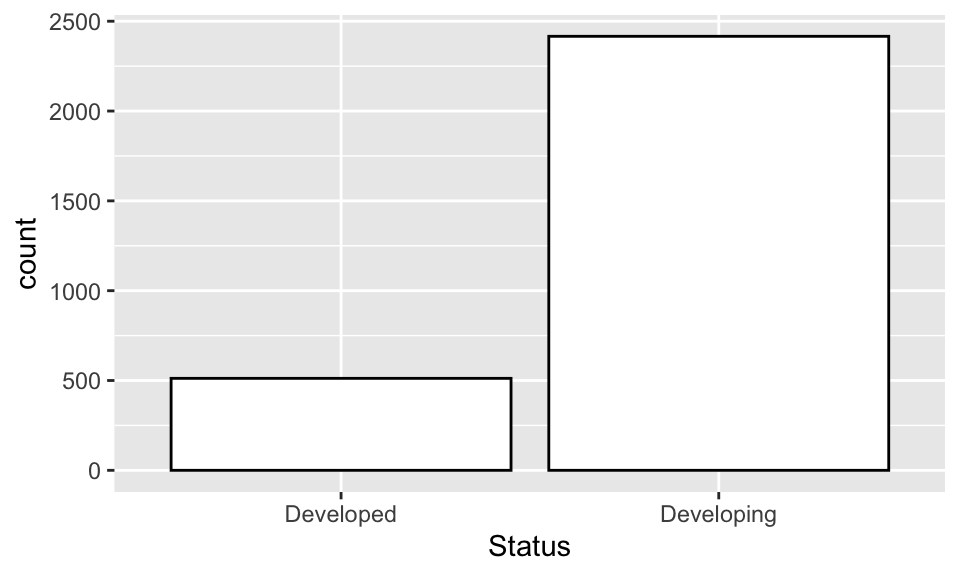

```r
ggplot(lifeDF, aes(x=Status)) +
  geom_histogram(color="black", fill="white", stat="count")
```

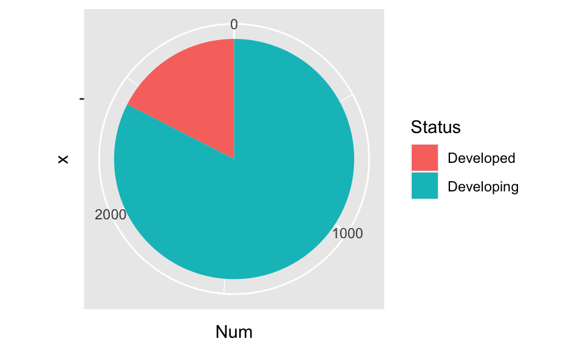

```r
lifeDF%>%group_by(Status)%>%summarise(Num = n())->status
ggplot(status, aes(x="", y=Num, fill=Status)) +
  geom_bar(stat="identity", width=1) +
  coord_polar("y", start=0)
```

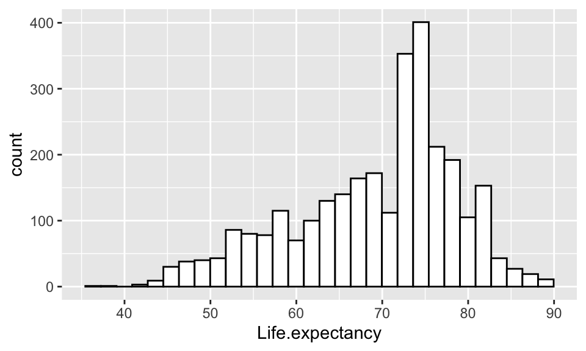

```r
ggplot(lifeDF, aes(x=Life.expectancy)) +
  geom_histogram(color="black", fill="white")
```

From the graphs we can see that we are looking at mostly developing countries in the dataset, and that life expectancy around 75 appears most in the data, where as under 50 and over 80 is more rare.

**Mean for a few columns relating to deaths:**

```r
colMeans(lifeDF%>%select(Life.expectancy, Adult.Mortality, infant.deaths, under.five.deaths))
```

```
##   Life.expectancy   Adult.Mortality     infant.deaths under.five.deaths
##          69.22493         164.79645          30.40745          42.17930
```

```r
lifeDF%>%group_by(Country)%>%summarise(Life.expectancy=mean(Life.expectancy))->life
life
```

```
## # A tibble: 183 x 2
##    Country             Life.expectancy
##    <chr>                         <dbl>
##  1 Afghanistan                    58.2
##  2 Albania                        75.2
##  3 Algeria                        73.6
##  4 Angola                         49.0
##  5 Antigua and Barbuda            75.1
##  6 Argentina                      75.2
##  7 Armenia                        73.4
##  8 Australia                      81.8
##  9 Austria                        81.5
## 10 Azerbaijan                     70.7
## # … with 173 more rows
```

```r
life%>%top_n(3, Life.expectancy)
```

```
## # A tibble: 3 x 2
##   Country Life.expectancy
##   <chr>             <dbl>
## 1 Iceland            82.4
## 2 Japan              82.5
## 3 Sweden             82.5
```

```r
life%>%slice_min(Life.expectancy, n=3)
```

```
## # A tibble: 3 x 2
##   Country                  Life.expectancy
##   <chr>                              <dbl>
## 1 Sierra Leone                        46.1
## 2 Central African Republic            48.5
## 3 Lesotho                             48.8
```

Top three countries with the highest avarage life expectancy are Iceland, Japan and Sweden, where the lowest are Sierra Leone, Central African Republic and Lesotho.

**How much did life expectancy rise(or not) in the fifteen years for each country (of those which have the data):**

```r
raise<-function(country){
  min = (lifeDF%>%filter(Country==as.character(country) & Year==2000))$Life.expectancy
  max = (lifeDF%>%filter(Country==as.character(country) & Year==2015))$Life.expectancy
  max-min
}
lifeDF%>%group_by(Country)%>%mutate(Change = raise(Country))%>%summarise(Change = mean(Change))->change
change
```

```
## # A tibble: 183 x 2
##    Country             Change
##    <chr>                <dbl>
##  1 Afghanistan          10.2
##  2 Albania               5.2
##  3 Algeria               4.30
##  4 Angola                7.1
##  5 Antigua and Barbuda   2.80
##  6 Argentina             2.20
##  7 Armenia               2.80
##  8 Australia             3.30
##  9 Austria               3.40
## 10 Azerbaijan            6.10
## # … with 173 more rows
```

```r
change%>%top_n(3, Change)
```

```
## # A tibble: 3 x 2
##   Country  Change
##   <chr>     <dbl>
## 1 Eritrea    19.4
## 2 Zambia     18
## 3 Zimbabwe   21
```

```r
change%>%slice_min(Change, n=3)
```

```
## # A tibble: 3 x 2
##   Country                          Change
##   <chr>                             <dbl>
## 1 Syrian Arab Republic              -8.10
## 2 Saint Vincent and the Grenadines  -5.8
## 3 Libya                             -5.3
```

Countries with the biggest jump in life expectancy are Eritrea, Zambia and Zimbabwe, where as expectancy fell in Syrian Arav Republic, Saint Vincent and the Grenadines and Libya.

**The avarage life expectancy for every year:**

```r
lifeDF%>%group_by(Year)%>%summarise(Life.expectancy=mean(Life.expectancy))->av
av
```

```
## # A tibble: 16 x 2
##     Year Life.expectancy
##    <int>           <dbl>
##  1  2000            66.8
##  2  2001            67.1
##  3  2002            67.4
##  4  2003            67.4
##  5  2004            67.6
##  6  2005            68.2
##  7  2006            68.7
##  8  2007            69.0
##  9  2008            69.4
## 10  2009            69.9
## 11  2010            70.0
## 12  2011            70.7
## 13  2012            70.9
## 14  2013            71.2
## 15  2014            71.5
## 16  2015            71.6
```

```r
difference = av$Life.expectancy%>%max-av$Life.expectancy%>%min
```

The average world life expectancy raised by 4.8666667 in the years 2000 to 2015, and was the highest in 2015.

**Countries with the lowest and highest life expectancy in 2000 are:**

```r
lifeDF%>%filter(Year==2000)%>%filter(Life.expectancy == min(Life.expectancy))%>%select(Country, Life.expectancy)
```

```
## # A tibble: 1 x 2
##   Country      Life.expectancy
##   <chr>                  <dbl>
## 1 Sierra Leone              39
```

```r
lifeDF%>%filter(Year==2000)%>%filter(Life.expectancy == max(Life.expectancy))%>%select(Country, Life.expectancy)
```

```
## # A tibble: 1 x 2
##   Country Life.expectancy
##   <chr>             <dbl>
## 1 Japan              81.1
```

In 2000, the country with the highest expectancy was Japan, where the result is over twice as much as in Sierra Leone, where it was the lowest at only 39.

**Countries with the lowest and highest life expectancy in 2015 are:**

```r
lifeDF%>%filter(Year==2015)%>%filter(Life.expectancy == min(Life.expectancy))%>%select(Country, Life.expectancy)
```

```
## # A tibble: 1 x 2
##   Country      Life.expectancy
##   <chr>                  <dbl>
## 1 Sierra Leone              51
```

```r
lifeDF%>%filter(Year==2015)%>%filter(Life.expectancy == max(Life.expectancy))%>%select(Country, Life.expectancy)
```

```
## # A tibble: 1 x 2
##   Country  Life.expectancy
##   <chr>              <dbl>
## 1 Slovenia              88
```

In 2015, the lowest was still in Sierra Leone, even though it did rise by 12 years, and was the highest is Slovenia, almost 7 years more than the highest age in 2000.

**The avarage life expectancy, adult mortality and infant mortality for developed and undeveloped countries:**

```r
lifeDF%>%group_by(Status)%>%summarise(Life.expectancy=mean(Life.expectancy), Adult.Mortality=mean(Adult.Mortality), infant.deaths = mean(infant.deaths))
```

```
## # A tibble: 2 x 4
##   Status     Life.expectancy Adult.Mortality infant.deaths
##   <chr>                <dbl>           <dbl>         <dbl>
## 1 Developed             79.2            79.7          1.49
## 2 Developing            67.1           183.          36.5
```

**Thinness in relation to income of countries:**

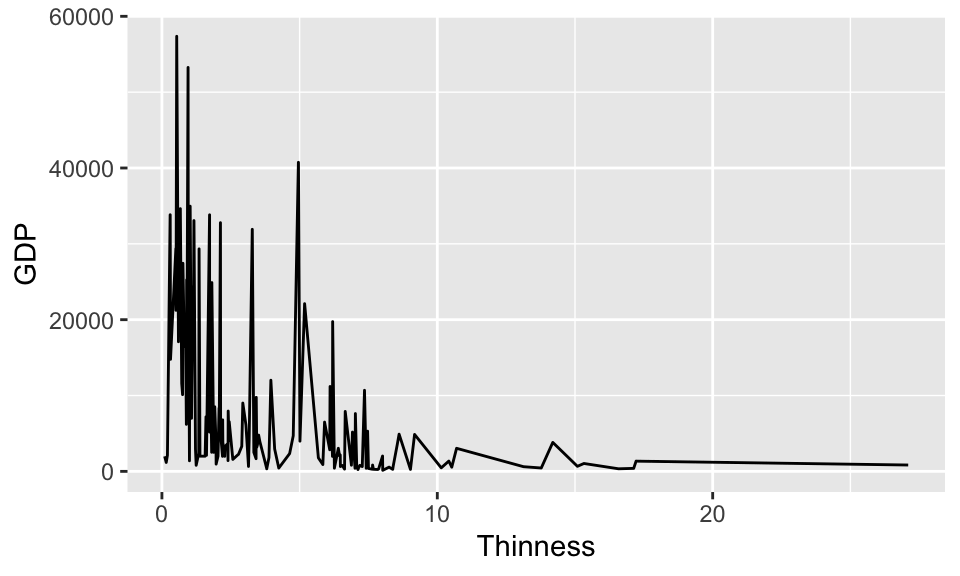

```r
lifeDF$BMI = as.numeric(lifeDF$BMI)
lifeDF$thinness..1.19.years = as.numeric(lifeDF$thinness..1.19.years)
lifeDF%>%group_by(Country)%>%summarise(Thinness=mean(thinness..1.19.years), GDP = mean(GDP))%>%filter(!is.na(Thinness), !is.na(GDP))->df1
df1%>%ggplot(aes(x=Thinness, y=GDP))+geom_line()
```

Another relation is between the Gross Domestic Product per capita (in USD) of the country and how many percantage of children are underweight. Unsurprisingly, we can see that, with a few exceptions, the poorer citizens are, the bigger percentage of children in underweight.

**Difference between life expectancy for developed and developing countries:**

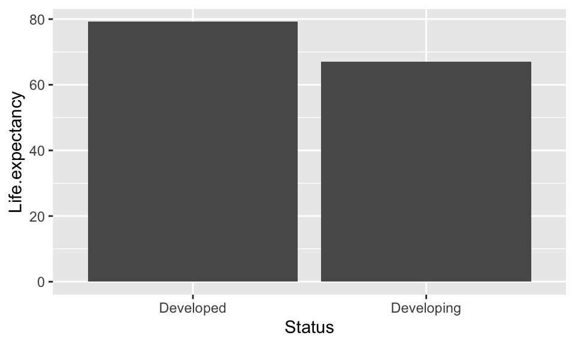

```r
lifeDF%>%group_by(Status)%>%summarise(Life.expectancy = mean(Life.expectancy))->stat1
ggplot(stat1, aes(x = Status, y = Life.expectancy)) +
       geom_bar(stat="identity")
```

By comparing the life expectancy for developed and undeveloped world, we can see the difference of about 12 years.

**And the, a lot more noticible difference between infant deaths in developed and undeveloped countries:**

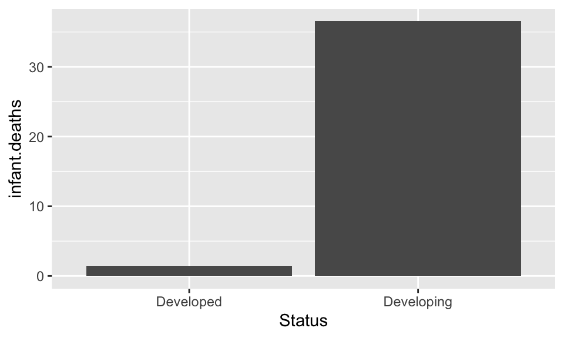

```r
lifeDF%>%group_by(Status)%>%summarise(infant.deaths = mean(infant.deaths))->infants
ggplot(infants, aes(x = Status, y = infant.deaths)) +
       geom_bar(stat="identity")
```

**Life expectancy in Slovenia for given 15 years:**

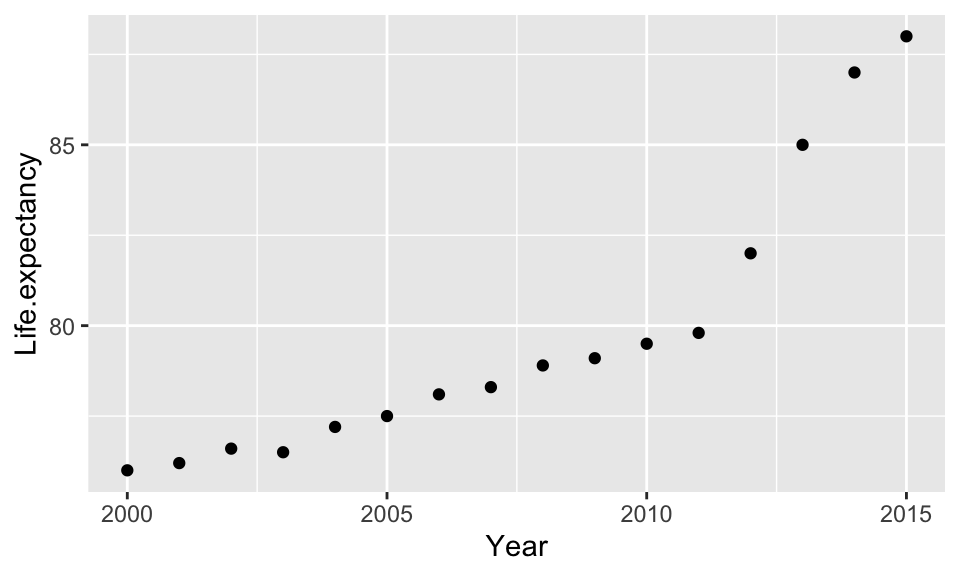

```r
lifeDF%>%filter(Country=="Slovenia")-> sl
ggplot(sl, aes(x=Year, y=Life.expectancy))+geom_point()
```

Looking only at the data for Slovenia, we can see a steady climb in life expectancy over the years, with a lot more steap climb in the most recent few years.

In conclusion, we can see that life expectancy has been steadily climbing in the 15 years the data was collected. There is a noticable difference between life expectancy in the developed and undeveloped world, but even bigger difference in number of infants per 1000 people that die, as well as number of adults that die between the ages 15 and 60. Unsurprisingly, the countries with the “best” results in each category are mostly western (mostly european) or Asian, and the ones with “worst” results are third world countries.

**References:**

- [Life expectancy](https://ourworldindata.org/life-expectancy)
- [Data](https://www.kaggle.com/kumarajarshi/life-expectancy-who/code)
- [Developing country](https://en.wikipedia.org/wiki/Developing_country)